# İstatistiksel Yöntemler 2 Ödevi

Ramazan Erduran - 21821809

23 12 2021

## Tek Yönlü ANOVA:

Verileri içeri aktarma.

```r
library(readxl)
crop_data <- read_excel("C:/Users/lenovo/Documents/GitHub/StatMeth2/Statistical-Methods-2/One_way_ANOVA/one_way_data.xlsx")
head(crop_data,3)
```

```
## # A tibble: 3 x 2
##   fertilizer yield
##        <dbl> <dbl>
## 1          1  177.
## 2          1  178.
## 3          1  176.
```

### Normallik testi:

H0: Verilerin dağılımı ile normal dağılım arasında fark yoktur.  
Hs: Verilerin dağılımı ile normal dağılım arasında fark vardır.

```r
shapiro.test(crop_data$yield)
```

```
##
##  Shapiro-Wilk normality test
##
## data:  crop_data$yield
## W = 0.989, p-value = 0.6135
```

%95 güven düzeyinde H0 reddedilemez. Verilerin dağılımı ile normal dağılım arasında fark yoktur.

### Varyans homojenliği:

H0: $\sigma$<sub>1</sub> = $\sigma$<sub>2</sub>  
Hs: $\sigma$<sub>1</sub> $\neq$ $\sigma$<sub>2</sub>

```r
bartlett.test(yield~fertilizer,data=crop_data)
```

```
##
##  Bartlett test of homogeneity of variances
##
## data:  yield by fertilizer
## Bartlett's K-squared = 1.0622, df = 2, p-value = 0.5879
```

%95 güven düzeyinde H0 reddedilemez. Varyanslar homojendir.

### ANOVA hesabı:

H0: Gübreler arasında fark yoktur.  
Hs: Gübreler arasında fark vardır.

```r
crop_data$fertilizer <- as.factor(crop_data$fertilizer)
rez_aov=lm( crop_data$yield ~ crop_data$fertilizer)
anova(aov(rez_aov))
```

```
## Analysis of Variance Table
##
## Response: crop_data$yield
##                      Df Sum Sq Mean Sq F value    Pr(>F)
## crop_data$fertilizer  2  6.068 3.03402  7.8628 0.0006999 ***
## Residuals            93 35.886 0.38587
## ---
## Signif. codes:  0 '***' 0.001 '**' 0.01 '*' 0.05 '.' 0.1 ' ' 1
```

%95 güven düzeyinde söylenebilir ki gübreler arası farklılık vardır.

### Post-Hoc testi:

```r
ANOVA=aov(rez_aov)
# Tukey test to study each pair of treatment :
TukeyHSD(x=ANOVA, 'crop_data$fertilizer', conf.level=0.95)
```

```
##   Tukey multiple comparisons of means
##     95% family-wise confidence level
##
## Fit: aov(formula = rez_aov)
##
## $`crop_data$fertilizer`
##          diff         lwr       upr     p adj
## 2-1 0.1761687 -0.19371896 0.5460564 0.4954705
## 3-1 0.5991256  0.22923789 0.9690133 0.0006125
## 3-2 0.4229569  0.05306916 0.7928445 0.0208735
```

2 ile 1 ….. fark anlamlı değil  
3 ile 1 ….. fark anlamlı  
3 ile 2 ….. fark anlamlı

### Özetleyici istatistikler:

```r
library(dplyr)
summary(crop_data[crop_data$fertilizer==1,])
```

```
##  fertilizer     yield
##  1:32       Min.   :175.4
##  2: 0       1st Qu.:176.1
##  3: 0       Median :176.8
##             Mean   :176.8
##             3rd Qu.:177.2
##             Max.   :178.4
```

```r
summary(crop_data[crop_data$fertilizer==2,])
```

```
##  fertilizer     yield
##  1: 0       Min.   :175.7
##  2:32       1st Qu.:176.5
##  3: 0       Median :177.0
##             Mean   :176.9
##             3rd Qu.:177.4
##             Max.   :178.1
```

```r
summary(crop_data[crop_data$fertilizer==3,])
```

```
##  fertilizer     yield
##  1: 0       Min.   :176.3
##  2: 0       1st Qu.:177.0
##  3:32       Median :177.3
##             Mean   :177.4
##             3rd Qu.:177.7
##             Max.   :179.1
```

Post Hoc testlerinden yararlanılarak %95 güvenle söylenebilir ki 3 numaralı gübre en iyisidir.

## Tekrarlı Ölçümlü ANOVA:

Verileri içeri aktarma.

```r
library(haven)
library(tidyverse)
library(ggpubr)
library(rstatix)
rept_data <- read_sav("~/GitHub/StatMeth2/Statistical-Methods-2/Repetitive_ANOVA/repeated_measures.sav")
head(rept_data,5)
```

```
## # A tibble: 5 x 4
##   TIME1 TIME2 TIME3 TIME4
##   <dbl> <dbl> <dbl> <dbl>
## 1    65    66    63    63
## 2    69    66    62    65
## 3    60    64    59    59
## 4    57    54    59    58
## 5    62    62    62    54
```

### Verileri manipüle etme:

```r
rept_data[,5] <- list(seq(1,30,1))
colnames(rept_data) <- c("TIME1","TIME2","TIME3","TIME4","id")

rp_factor <- rept_data %>%
  gather(key = "time", value = "score", TIME1, TIME2, TIME3, TIME4) %>%
  convert_as_factor(id,time)

head(rp_factor, 3)
```

```
## # A tibble: 3 x 3
##   id    time  score
##   <fct> <fct> <dbl>
## 1 1     TIME1    65
## 2 2     TIME1    69
## 3 3     TIME1    60
```

### Ortalama ve St. Sapma değerleri:

```r
rp_factor%>%
  group_by(time) %>%
  get_summary_stats(score, type = "mean_sd")
```

```
## # A tibble: 4 x 5
##   time  variable     n  mean    sd
##   <fct> <chr>    <dbl> <dbl> <dbl>
## 1 TIME1 score       30  65.8  9.23
## 2 TIME2 score       30  65.4 10.7
## 3 TIME3 score       30  63.1 10.7
## 4 TIME4 score       30  61.9 12.6
```

### Extreme Aykırı değer kontrolü:

```r
rp_factor %>%
  group_by(time) %>%
  identify_outliers(score)
```

```
## # A tibble: 11 x 5
##    time  id    score is.outlier is.extreme
##    <fct> <fct> <dbl> <lgl>      <lgl>
##  1 TIME2 11       85 TRUE       FALSE
##  2 TIME2 18       85 TRUE       FALSE
##  3 TIME2 28       41 TRUE       FALSE
##  4 TIME3 8        83 TRUE       FALSE
##  5 TIME3 11       83 TRUE       FALSE
##  6 TIME3 18       84 TRUE       FALSE
##  7 TIME3 23       78 TRUE       FALSE
##  8 TIME3 24       80 TRUE       FALSE
##  9 TIME3 25       42 TRUE       FALSE
## 10 TIME3 28       43 TRUE       FALSE
## 11 TIME4 24       91 TRUE       FALSE
```

“EXTREME” bir aykırı değer yok.

### Normallik testi:

H0: Verilerin dağılımı ile normal dağılım arasında fark yoktur.  
Hs: Verilerin dağılımı ile normal dağılım arasında fark vardır.

```r
rp_factor %>%
  group_by(time) %>%
  shapiro_test(score)
```

```
## # A tibble: 4 x 4
##   time  variable statistic      p
##   <fct> <chr>        <dbl>  <dbl>
## 1 TIME1 score        0.963 0.364
## 2 TIME2 score        0.962 0.358
## 3 TIME3 score        0.936 0.0697
## 4 TIME4 score        0.966 0.432
```

Tüm değişkenler adına p>0.05 için H0 reddedilemez. Hepsi normal dağılıyor denebilir.

### Varyans homojenliği:

H0: $\sigma$<sub>1</sub> = $\sigma$<sub>2</sub> = $\sigma$<sub>3</sub> = $\sigma$<sub>4</sub>  
Hs: En az bir $\sigma$<sub>i</sub> farklıdır.

```r
bartlett.test(score~time,data=rp_factor)
```

```
##
##  Bartlett test of homogeneity of variances
##
## data:  score by time
## Bartlett's K-squared = 2.7425, df = 3, p-value = 0.433
```

Test sonucuna göre p > 0.05 için söylenebilir ki varyanslar homojendir.

### ANOVA testi:

H0: Zamanlar arası fark yoktur.  
Hs: En az bir zamana ait değerler farklıdır.

```r
rp_factor$time <- as.factor(rp_factor$time)
rez_aov=lm( rp_factor$score ~ rp_factor$time)
anova(aov(rez_aov))
```

```
## Analysis of Variance Table
##
## Response: rp_factor$score
##                 Df  Sum Sq Mean Sq F value Pr(>F)
## rp_factor$time   3   310.7  103.58  0.8789 0.4543
## Residuals      116 13670.7  117.85
```

[(F<sub>h</sub>=0.878) < (F<sub>t</sub>=3,15)] aynı zamanda P<sub>value</sub>=0.4543 > alpha=0.05 için;  
H0 hipotezi reddedilemez. Yani zamanlar arasında farklılık yoktur.

## Rastgele Blok:

verileri içeri aktarma

```r
library(readxl)
cb_data<- read_excel("~/GitHub/StatMeth2/Statistical-Methods-2/Randomized_Block_ANOVA/castle_bakery_data.xlsx")
colnames(cb_data) <- c("Heights","Display_regular","Display_wide")
head(cb_data)
```

```
## # A tibble: 6 x 3
##   Heights Display_regular Display_wide
##   <chr>             <dbl>        <dbl>
## 1 Bottom               47           46
## 2 Bottom               43           40
## 3 Middle               62           67
## 4 Middle               68           71
## 5 Top                  41           42
## 6 Top                  39           46
```

### Normallik testi:

H0: Verilerin dağılımı ile normal dağılım arasında fark yoktur.  
Hs: Verileirn dağılımı ile normal dağılım arasında fark vardır.

```r
shapiro.test(cb_data$Display_regular)
```

```
##
##  Shapiro-Wilk normality test
##
## data:  cb_data$Display_regular
## W = 0.85126, p-value = 0.1611
```

```r
shapiro.test(cb_data$Display_wide)
```

```
##
##  Shapiro-Wilk normality test
##
## data:  cb_data$Display_wide
## W = 0.80521, p-value = 0.06544
```

%95 güven düzeyinde, bütün oynatma türü verileri normal dağılıyor denebilir.

### Verileri manipüle etme:

```r
cb_data <- cb_data %>%
  gather(key = "kind", value = "value", Display_regular, Display_wide) %>%
  convert_as_factor(Heights,kind)
```

### Varyans homojenliği:

H0: $\sigma$<sub>Bottom</sub> = $\sigma$<sub>Middle</sub> = $\sigma$<sub>Top</sub>  
Hs: En az bir $\sigma$<sub>i</sub> farklıdır.

```r
bartlett.test(value ~ Heights, data=cb_data)
```

```
##
##  Bartlett test of homogeneity of variances
##
## data:  value by Heights
## Bartlett's K-squared = 0.16227, df = 2, p-value = 0.9221
```

P-value > 0.05 için H0 reddedilemez. Bu nedenle söylenebilir ki varyanslar homojendir.

### ANOVA testi:

H0: Plakların oynatma yerleri arasında fark yoktur.  
Hs: Plakların oynatma yerleri arasında fark vardır.

```r
fit <- aov(value ~ Heights + kind, data = cb_data)
summary(fit)
```

```
##             Df Sum Sq Mean Sq F value   Pr(>F)
## Heights      2   1544   772.0  71.814 7.75e-06 ***
## kind         1     12    12.0   1.116    0.322
## Residuals    8     86    10.8
## ---
## Signif. codes:  0 '***' 0.001 '**' 0.01 '*' 0.05 '.' 0.1 ' ' 1
```

P < 0.05 için H0 reddedilir. Yani oynatma yerleri arasında farklılık vardır.

### Post Hoc testi:

```r
TukeyHSD(fit ,conf.level=0.95)
```

```
##   Tukey multiple comparisons of means
##     95% family-wise confidence level
##
## Fit: aov(formula = value ~ Heights + kind, data = cb_data)
##
## $Heights
##               diff        lwr        upr     p adj
## Middle-Bottom   23  16.375288  29.624712 0.0000236
## Top-Bottom      -2  -8.624712   4.624712 0.6771042
## Top-Middle     -25 -31.624712 -18.375288 0.0000126
##
## $kind
##                              diff       lwr      upr     p adj
## Display_wide-Display_regular    2 -2.365195 6.365195 0.3215794
```

Middle ile Bottom ….. fark anlamlı.  
Top ile Bottom ….. fark anlamlı değil.  
Top ile Middle ….. fark anlamlı  
Tukey testinin sonucuna göre söylenebilir ki “Middle” seviyesindeki oynatma en iyisidir.

## Latin Kare:

Verileri içeri aktarma:

```r
library(readxl)
data = read_excel(path = "C:/Users/lenovo/Documents/GitHub/StatMeth2/Statistical-Methods-2/Latin_Square/data_ls.xlsx",
                col_names = TRUE)

head(data,5)
```

```
## # A tibble: 5 x 4
##     Row Column Varieties Yield
##   <dbl>  <dbl> <chr>     <dbl>
## 1     1      1 B          1.64
## 2     1      2 D          1.21
## 3     1      3 C          1.42
## 4     1      4 A          1.34
## 5     2      1 C          1.48
```

```r
#Veri yapısına bakılıp satır sütun görselleştirmesi yapıldığında:
#---1-2-3-4-
#-1-B-D-C-A-
#-2-C-A-D-B-
#-3-A-C-B-D-
#-4-D-B-A-C-
#Şeklindeki latin kare veri setimiz ortaya çıkmaktadır.
```

### Veriyi manipüle etme:

```r
data$Row <- as.factor(data$Row)
data$Column <- as.factor(data$Column)
data$Varieties <- as.factor(data$Varieties)
str(data)
```

```
## tibble [16 x 4] (S3: tbl_df/tbl/data.frame)
##  $ Row      : Factor w/ 4 levels "1","2","3","4": 1 1 1 1 2 2 2 2 3 3 ...
##  $ Column   : Factor w/ 4 levels "1","2","3","4": 1 2 3 4 1 2 3 4 1 2 ...
##  $ Varieties: Factor w/ 4 levels "A","B","C","D": 2 4 3 1 3 1 4 2 1 3 ...
##  $ Yield    : num [1:16] 1.64 1.21 1.42 1.34 1.48 ...
```

### ANOVA testi:

```r
attach(data)
model <- lm(Yield ~ Row+Column+Varieties)
anova(model)
```

```
## Analysis of Variance Table
##
## Response: Yield
##           Df  Sum Sq  Mean Sq F value   Pr(>F)
## Row        3 0.03015 0.010052  0.4654 0.716972
## Column     3 0.82734 0.275781 12.7692 0.005148 **
## Varieties  3 0.42684 0.142281  6.5879 0.025092 *
## Residuals  6 0.12958 0.021597
## ---
## Signif. codes:  0 '***' 0.001 '**' 0.01 '*' 0.05 '.' 0.1 ' ' 1
```

P değerlerine göre %95 güven düzeyinde;  
Satırlar arası farklılık yoktur.  
Sütunlar arası farklılık vardır.  
Çeşitler arası farklılık vardır yorumları yapılabilir.

### Ortalama karşılaştırma testi:

```r
library(agricolae)
# LSD test
LSD.test(y = model,trt = "Varieties",DFerror = model$df.residual,MSerror = deviance(model)/model$df.residual,alpha = 0.05,group = TRUE,console = TRUE)
```

```
##
## Study: model ~ "Varieties"
##
## LSD t Test for Yield
##
## Mean Square Error:  0.0215974
##
## Varieties,  means and individual ( 95 %) CI
##
##     Yield       std r       LCL     UCL   Min   Max
## A 1.46375 0.2386900 4 1.2839503 1.64355 1.185 1.670
## B 1.47125 0.2095382 4 1.2914503 1.65105 1.290 1.665
## C 1.06750 0.4426153 4 0.8877003 1.24730 0.660 1.475
## D 1.33875 0.1795538 4 1.1589503 1.51855 1.180 1.565
##
## Alpha: 0.05 ; DF Error: 6
## Critical Value of t: 2.446912
##
## least Significant Difference: 0.2542752
##
## Treatments with the same letter are not significantly different.
##
##     Yield groups
## B 1.47125      a
## A 1.46375      a
## D 1.33875      a
## C 1.06750      b
```

```r
# SNK test
SNK.test(y = Yield,trt = Varieties,DFerror = model$df.residual,MSerror = deviance(model)/model$df.residual,alpha = 0.05,group = TRUE,console = TRUE)
```

```
##
## Study: Yield ~ Varieties
##
## Student Newman Keuls Test
## for Yield
##
## Mean Square Error:  0.0215974
##
## Varieties,  means
##
##     Yield       std r   Min   Max
## A 1.46375 0.2386900 4 1.185 1.670
## B 1.47125 0.2095382 4 1.290 1.665
## C 1.06750 0.4426153 4 0.660 1.475
## D 1.33875 0.1795538 4 1.180 1.565
##
## Alpha: 0.05 ; DF Error: 6
##
## Critical Range
##         2         3         4
## 0.2542752 0.3188452 0.3597299
##
## Means with the same letter are not significantly different.
##
##     Yield groups
## B 1.47125      a
## A 1.46375      a
## D 1.33875      a
## C 1.06750      b
```

## Çok Etkenli Deney Düzeni:

Verileri içeri aktarma.

```r
library(readr)
library(dplyr)
lab_data <- read_table("~/GitHub/StatMeth2/Statistical-Methods-2/Multifactor_Setup/JAHANMI2.DAT.txt",col_types = cols(Lab = col_factor(levels = c("1","2", "3", "4", "5", "6", "7", "8"))))

head(lab_data)
```

```
## # A tibble: 6 x 16
##      Id Lab     Num  Test     Y    X1    X2    X3    X4   Trt   Set  Llab   Rep
##   <dbl> <fct> <dbl> <dbl> <dbl> <dbl> <dbl> <dbl> <dbl> <dbl> <dbl> <dbl> <dbl>
## 1     1 1         1     1  609.    -1    -1    -1    -1     1     1  0.75     1
## 2     2 1         2     1  570.    -1    -1    -1    -1     1     1  0.75     1
## 3     3 1         3     1  690.    -1    -1    -1    -1     1     1  0.75     1
## 4     4 1         4     1  748.    -1    -1    -1    -1     1     1  0.75     1
## 5     5 1         5     1  618.    -1    -1    -1    -1     1     1  0.75     1
## 6     6 1         6     1  612.    -1    -1    -1    -1     1     1  0.75     1
## # ... with 3 more variables: Bat <dbl>, Sblab <dbl>, Set2 <dbl>
```

### Verileri manipüle etme:

Daha anlaşılabilir ve daha kolay işlenebilir hale getirmek için üzerinde inceleme yapacağımız değişkenleri ayırdık.

```r
lab_edited <- lab_data %>%
  summarize(Lab=Lab, X3=X3, Y=Y)
head(lab_edited,5)
```

```
## # A tibble: 5 x 3
##   Lab      X3     Y
##   <fct> <dbl> <dbl>
## 1 1        -1  609.
## 2 1        -1  570.
## 3 1        -1  690.
## 4 1        -1  748.
## 5 1        -1  618.
```

### ANOVA testi:

```r
res_1<- lm(Y ~ Lab*as.factor(X3), data=lab_edited)
anova(res_1)
```

```
## Analysis of Variance Table
##
## Response: Y
##                    Df  Sum Sq Mean Sq F value  Pr(>F)
## Lab                 7   70755   10108  1.8791 0.07113 .
## as.factor(X3)       1   14380   14380  2.6733 0.10272
## Lab:as.factor(X3)   7   87451   12493  2.3226 0.02453 *
## Residuals         464 2495861    5379
## ---
## Signif. codes:  0 '***' 0.001 '**' 0.01 '*' 0.05 '.' 0.1 ' ' 1
```

%95 Güven düzeyinde etkileşimler önemlidir.  
%95 Güven düzeyinde lab etkeni önemsizdir.  
%95 Güven düzeyinde X3 etkeni önemsizdir yorumları yapılabilir.

### Etkileşim grafikleri:

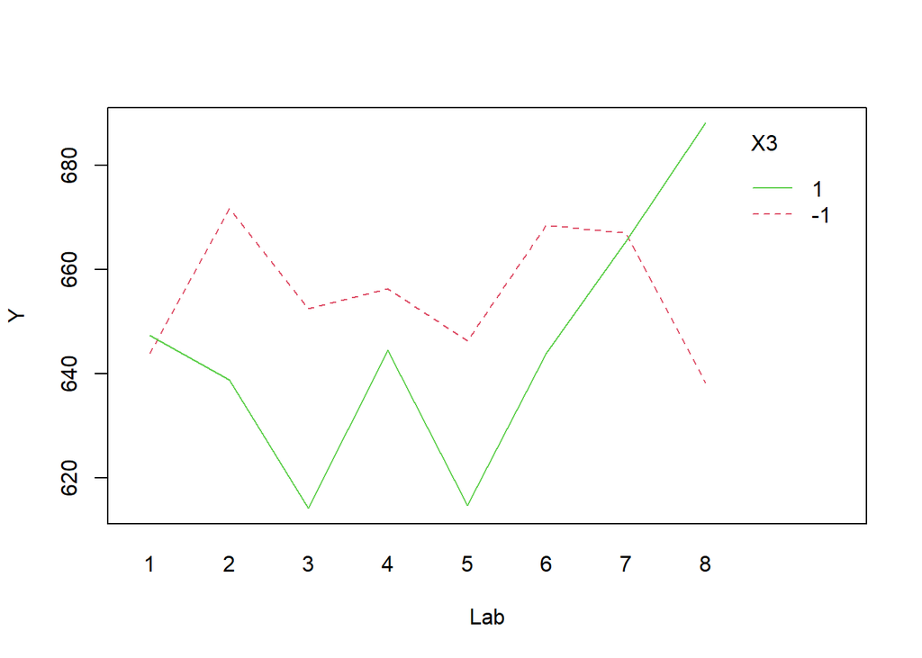

```r
attach(lab_edited)
interaction.plot(Lab, X3, Y, type = "l",
xlab = "Lab",trace.label = "X3",
ylab = "Y", col=c(2,3,4))
```

## Kaynakça:

Tek Yönlü Anova Kaynağı: [Scribbr](https://www.scribbr.com)  
Tekrarlı Ölçümlü anova Kaynağı: [Google Drive](https://drive.google.com/file/d/0B0BsVnmXOaHwdzVYd05ZWjROQjg/view?resourcekey=0-yaqC7XcttKTgjEENapzhVg)  
Rastgele Blok Kaynağı: [National Institute of Standarts and Technology](https://www.nist.gov)  
Latin Kare Kaynağı: [Agron Info Tech](https://agroninfotech.blogspot.com)  
Çok Etkenli Deney Düzeni Kaynağı: [Information Technology Laboratory](https://www.nist.gov/itl)